# A Replication of Karlan and List (2007)

Author

Puja Malik

Published

May 27, 2025

## 1 Introduction

Dean Karlan at Yale and John List at the University of Chicago conducted a field experiment to test the effectiveness of different fundraising letters. They sent out 50,000 fundraising letters to potential donors, randomly assigning each letter to one of three treatments: a standard letter, a matching grant letter, or a challenge grant letter. They published the results of this experiment in the *American Economic Review* in 2007. The article and supporting data are available from the [AEA website](https://www.aeaweb.org/articles?id=10.1257/aer.97.5.1774) and from Innovations for Poverty Action as part of [Harvard’s Dataverse](https://dataverse.harvard.edu/dataset.xhtml?persistentId=doi:10.7910/DVN/27853&version=4.2).

The core experimental treatments varied along three main dimensions:

Presence of a matching grant: Some letters simply asked for a donation (control), while others offered to match the recipient’s contribution at a 1:1, 2:1, or 3:1 rate up to a certain threshold.

Size of the match: Within the treatment group, participants were randomly assigned to receive one of three match ratios — $1:$1, $2:$1, or $3:$1.

Suggested donation amount and maximum match amount were also randomly varied across treatment groups to test for framing and price anchoring effects.

The outcome variables of interest were (a) whether a donation was made, and (b) the amount donated. The authors found that mentioning a matching offer significantly increased both the probability of giving and total revenue, but that higher match ratios (e.g., 3:1) did not lead to additional increases beyond the basic 1:1 match.

This project seeks to replicate their results.

## 2 Data

### 2.1 Description

```python
import pandas as pd
df = pd.read_stata("karlan_list_2007.dta")

# Basic summary
num_obs, num_vars = df.shape
print(f"The dataset contains {num_obs:,} observations and {num_vars} variables.\n")

# Display column types and missing values
print("Variable types and number of missing values:\n")
print(df.dtypes.value_counts())
print("\nTop 5 variables with most missing values:")
print(df.isnull().sum().sort_values(ascending=False).head())

# Summary stats for key variables
key_vars = ['treatment', 'gave', 'amount', 'hpa', 'freq', 'mrm2', 'female']
print("\nSummary statistics (selected variables):\n")
print(df[key_vars].describe(include='all'))
```

```
The dataset contains 50,083 observations and 51 variables.

Variable types and number of missing values:

int8        16
float32     16
float64     12
int16        4
category     1
category     1
category     1
Name: count, dtype: int64

Top 5 variables with most missing values:
pblack             2036
median_hhincome    1874
powner             1869
psch_atlstba       1868
page18_39          1866
dtype: int64

Summary statistics (selected variables):

          treatment          gave        amount           hpa          freq  \
count  50083.000000  50083.000000  50083.000000  50083.000000  50083.000000
mean       0.666813      0.020646      0.915694     59.384975      8.039355
std        0.471357      0.142197      8.709199     71.177307     11.394454
min        0.000000      0.000000      0.000000      0.000000      0.000000
25%        0.000000      0.000000      0.000000     30.000000      2.000000
50%        1.000000      0.000000      0.000000     45.000000      4.000000
75%        1.000000      0.000000      0.000000     60.000000     10.000000
max        1.000000      1.000000    400.000000   1000.000000    218.000000

               mrm2        female
count  50082.000000  48972.000000
mean      13.007268      0.277669
std       12.081403      0.447854
min        0.000000      0.000000
25%        4.000000      0.000000
50%        8.000000      0.000000
75%       19.000000      1.000000
max      168.000000      1.000000
```

**Variable Definitions**

| Variable | Description |
| --- | --- |
| `treatment` | Treatment |
| `control` | Control |
| `ratio` | Match ratio |
| `ratio2` | 2:1 match ratio |
| `ratio3` | 3:1 match ratio |
| `size` | Match threshold |
| `size25` | $25,000 match threshold |
| `size50` | $50,000 match threshold |
| `size100` | $100,000 match threshold |
| `sizeno` | Unstated match threshold |
| `ask` | Suggested donation amount |
| `askd1` | Suggested donation was highest previous contribution |
| `askd2` | Suggested donation was 1.25 x highest previous contribution |
| `askd3` | Suggested donation was 1.50 x highest previous contribution |
| `ask1` | Highest previous contribution (for suggestion) |
| `ask2` | 1.25 x highest previous contribution (for suggestion) |
| `ask3` | 1.50 x highest previous contribution (for suggestion) |
| `amount` | Dollars given |
| `gave` | Gave anything |
| `amountchange` | Change in amount given |
| `hpa` | Highest previous contribution |
| `ltmedmra` | Small prior donor: last gift was less than median $35 |
| `freq` | Number of prior donations |
| `years` | Number of years since initial donation |
| `year5` | At least 5 years since initial donation |
| `mrm2` | Number of months since last donation |
| `dormant` | Already donated in 2005 |
| `female` | Female |
| `couple` | Couple |
| `state50one` | State tag: 1 for one observation of each of 50 states; 0 otherwise |
| `nonlit` | Nonlitigation |
| `cases` | Court cases from state in 2004-5 in which organization was involved |
| `statecnt` | Percent of sample from state |
| `stateresponse` | Proportion of sample from the state who gave |
| `stateresponset` | Proportion of treated sample from the state who gave |
| `stateresponsec` | Proportion of control sample from the state who gave |
| `stateresponsetminc` | stateresponset - stateresponsec |
| `perbush` | State vote share for Bush |
| `close25` | State vote share for Bush between 47.5% and 52.5% |
| `red0` | Red state |
| `blue0` | Blue state |
| `redcty` | Red county |
| `bluecty` | Blue county |
| `pwhite` | Proportion white within zip code |
| `pblack` | Proportion black within zip code |
| `page18_39` | Proportion age 18-39 within zip code |
| `ave_hh_sz` | Average household size within zip code |
| `median_hhincome` | Median household income within zip code |
| `powner` | Proportion house owner within zip code |
| `psch_atlstba` | Proportion who finished college within zip code |
| `pop_propurban` | Proportion of population urban within zip code |

### 2.2 Balance Test

As an ad hoc test of the randomization mechanism, I provide a series of tests that compare aspects of the treatment and control groups to assess whether they are statistically significantly different from one another.

```
                            OLS Regression Results
==============================================================================
Dep. Variable:                   mrm2   R-squared:                       0.000
Model:                            OLS   Adj. R-squared:                 -0.000
Method:                 Least Squares   F-statistic:                   0.01428
Date:                Wed, 23 Apr 2025   Prob (F-statistic):              0.905
Time:                        08:17:42   Log-Likelihood:            -1.9585e+05
No. Observations:               50082   AIC:                         3.917e+05
Df Residuals:                   50080   BIC:                         3.917e+05
Df Model:                           1
Covariance Type:            nonrobust
==============================================================================
                 coef    std err          t      P>|t|      [0.025      0.975]
------------------------------------------------------------------------------
Intercept     12.9981      0.094    138.979      0.000      12.815      13.181
treatment      0.0137      0.115      0.119      0.905      -0.211       0.238
==============================================================================
Omnibus:                     8031.352   Durbin-Watson:                   2.004
Prob(Omnibus):                  0.000   Jarque-Bera (JB):            12471.135
Skew:                           1.163   Prob(JB):                         0.00
Kurtosis:                       3.751   Cond. No.                         3.23
==============================================================================

Notes:
[1] Standard Errors assume that the covariance matrix of the errors is correctly specified.
                            OLS Regression Results
==============================================================================
Dep. Variable:                   freq   R-squared:                       0.000
Model:                            OLS   Adj. R-squared:                 -0.000
Method:                 Least Squares   F-statistic:                   0.01181
Date:                Wed, 23 Apr 2025   Prob (F-statistic):              0.913
Time:                        08:17:42   Log-Likelihood:            -1.9292e+05
No. Observations:               50082   AIC:                         3.858e+05
Df Residuals:                   50080   BIC:                         3.859e+05
Df Model:                           1
Covariance Type:            nonrobust
==============================================================================
                 coef    std err          t      P>|t|      [0.025      0.975]
------------------------------------------------------------------------------
Intercept      8.0473      0.088     91.231      0.000       7.874       8.220
treatment     -0.0117      0.108     -0.109      0.913      -0.223       0.200
==============================================================================
Omnibus:                    49106.033   Durbin-Watson:                   2.016
Prob(Omnibus):                  0.000   Jarque-Bera (JB):          3644674.385
Skew:                           4.707   Prob(JB):                         0.00
Kurtosis:                      43.718   Cond. No.                         3.23
==============================================================================

Notes:
[1] Standard Errors assume that the covariance matrix of the errors is correctly specified.
To check the validity of the randomization, I compared two pre-treatment covariates: the number of months since the last donation (mrm2) and the number of prior donations (freq).

For mrm2, the two-sample t-test returned a p-value of 0.9049, indicating no statistically significant difference. The linear regression of mrm2 on treatment gives a coefficient of 0.0137 with a p-value of 0.9049.

For freq, the t-test p-value was 0.9135, and the regression coefficient on treatment was -0.0117 with a p-value of 0.9135.

These results confirm that the treatment and control groups are statistically indistinguishable on these variables, consistent with Table 1 in Karlan & List (2007). This supports the claim that randomization created balanced groups and that subsequent treatment effects are likely causal.
```

## 3 Experimental Results

[figure not shown]

Proportion of Respondents Who Donated by Group

```python
from scipy.stats import ttest_ind
import statsmodels.formula.api as smf

df_gave = df[['treatment', 'gave']].dropna()

treat = df_gave[df_gave['treatment'] == 1]['gave']
control = df_gave[df_gave['treatment'] == 0]['gave']
t_stat, p_val = ttest_ind(treat, control)

model = smf.ols('gave ~ treatment', data=df_gave).fit()

print(f"T-test: t = {t_stat:.4f}, p = {p_val:.4f}")
print(model.summary())
```

```
T-test: t = 3.1014, p = 0.0019
                            OLS Regression Results
==============================================================================
Dep. Variable:                   gave   R-squared:                       0.000
Model:                            OLS   Adj. R-squared:                  0.000
Method:                 Least Squares   F-statistic:                     9.618
Date:                Wed, 23 Apr 2025   Prob (F-statistic):            0.00193
Time:                        08:17:42   Log-Likelihood:                 26630.
No. Observations:               50083   AIC:                        -5.326e+04
Df Residuals:                   50081   BIC:                        -5.324e+04
Df Model:                           1
Covariance Type:            nonrobust
==============================================================================
                 coef    std err          t      P>|t|      [0.025      0.975]
------------------------------------------------------------------------------
Intercept      0.0179      0.001     16.225      0.000       0.016       0.020
treatment      0.0042      0.001      3.101      0.002       0.002       0.007
==============================================================================
Omnibus:                    59814.280   Durbin-Watson:                   2.005
Prob(Omnibus):                  0.000   Jarque-Bera (JB):          4317152.727
Skew:                           6.740   Prob(JB):                         0.00
Kurtosis:                      46.440   Cond. No.                         3.23
==============================================================================

Notes:
[1] Standard Errors assume that the covariance matrix of the errors is correctly specified.
```

[output not shown]

### 3.1 Charitable Contribution Made

First, I analyze whether matched donations lead to an increased response rate of making a donation.

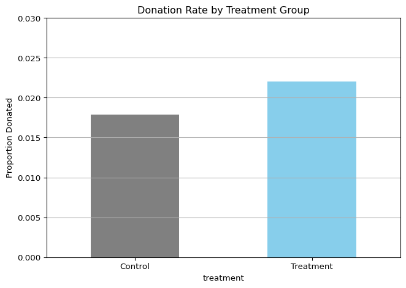

Donation Rate by Treatment Status

```
T-test: t = 3.1014, p = 0.0019

Linear regression result:
                             OLS Regression Results
==============================================================================
Dep. Variable:                   gave   R-squared:                       0.000
Model:                            OLS   Adj. R-squared:                  0.000
Method:                 Least Squares   F-statistic:                     9.618
Date:                Wed, 23 Apr 2025   Prob (F-statistic):            0.00193
Time:                        08:17:42   Log-Likelihood:                 26630.
No. Observations:               50083   AIC:                        -5.326e+04
Df Residuals:                   50081   BIC:                        -5.324e+04
Df Model:                           1
Covariance Type:            nonrobust
==============================================================================
                 coef    std err          t      P>|t|      [0.025      0.975]
------------------------------------------------------------------------------
Intercept      0.0179      0.001     16.225      0.000       0.016       0.020
treatment      0.0042      0.001      3.101      0.002       0.002       0.007
==============================================================================
Omnibus:                    59814.280   Durbin-Watson:                   2.005
Prob(Omnibus):                  0.000   Jarque-Bera (JB):          4317152.727
Skew:                           6.740   Prob(JB):                         0.00
Kurtosis:                      46.440   Cond. No.                         3.23
==============================================================================

Notes:
[1] Standard Errors assume that the covariance matrix of the errors is correctly specified.

Probit regression result:
                           Probit Regression Results
==============================================================================
Dep. Variable:                   gave   No. Observations:                50083
Model:                         Probit   Df Residuals:                    50081
Method:                           MLE   Df Model:                            1
Date:                Wed, 23 Apr 2025   Pseudo R-squ.:               0.0009783
Time:                        08:17:42   Log-Likelihood:                -5030.5
converged:                       True   LL-Null:                       -5035.4
Covariance Type:            nonrobust   LLR p-value:                  0.001696
==============================================================================
                 coef    std err          z      P>|z|      [0.025      0.975]
------------------------------------------------------------------------------
Intercept     -2.1001      0.023    -90.073      0.000      -2.146      -2.054
treatment      0.0868      0.028      3.113      0.002       0.032       0.141
==============================================================================
```

### 3.2 Differences between Match Rates

Next, I assess the effectiveness of different sizes of matched donations on the response rate.

```python
import pandas as pd
from scipy.stats import ttest_ind
import statsmodels.formula.api as smf

# Filter treatment group only
df_match = df[df['treatment'] == 1].copy()

# T-tests between match ratios
gave_1to1 = df_match[df_match['ratio'] == 1]['gave'].dropna()
gave_2to1 = df_match[df_match['ratio2'] == 1]['gave'].dropna()
gave_3to1 = df_match[df_match['ratio3'] == 1]['gave'].dropna()

# T-tests
t_12, p_12 = ttest_ind(gave_1to1, gave_2to1)
t_23, p_23 = ttest_ind(gave_2to1, gave_3to1)

# Regression: categorical ratio
model_cat = smf.ols('gave ~ C(ratio)', data=df_match).fit()

# Output
print(f"T-test 1:1 vs 2:1 → p = {p_12:.4f}")
print(f"T-test 2:1 vs 3:1 → p = {p_23:.4f}\n")

print(model_cat.summary())

# Response rate differences from data
mean_1to1 = gave_1to1.mean()
mean_2to1 = gave_2to1.mean()
mean_3to1 = gave_3to1.mean()

print(f"\nResponse Rates:")
print(f"1:1 = {mean_1to1:.4f}")
print(f"2:1 = {mean_2to1:.4f}")
print(f"3:1 = {mean_3to1:.4f}")

print(f"\nDifferences (from raw data):")
print(f"2:1 − 1:1 = {mean_2to1 - mean_1to1:.4f}")
print(f"3:1 − 2:1 = {mean_3to1 - mean_2to1:.4f}")
```

```
T-test 1:1 vs 2:1 → p = 0.3345
T-test 2:1 vs 3:1 → p = 0.9600

                            OLS Regression Results
==============================================================================
Dep. Variable:                   gave   R-squared:                       0.000
Model:                            OLS   Adj. R-squared:                 -0.000
Method:                 Least Squares   F-statistic:                    0.4291
Date:                Wed, 23 Apr 2025   Prob (F-statistic):              0.732
Time:                        08:17:42   Log-Likelihood:                 16688.
No. Observations:               33396   AIC:                        -3.337e+04
Df Residuals:                   33392   BIC:                        -3.333e+04
Df Model:                           3
Covariance Type:            nonrobust
=================================================================================
                    coef    std err          t      P>|t|      [0.025      0.975]
---------------------------------------------------------------------------------
Intercept      1.246e+09   2.14e+10      0.058      0.954   -4.07e+10    4.32e+10
C(ratio)[T.1] -1.246e+09   2.14e+10     -0.058      0.954   -4.32e+10    4.07e+10
C(ratio)[T.2] -1.246e+09   2.14e+10     -0.058      0.954   -4.32e+10    4.07e+10
C(ratio)[T.3] -1.246e+09   2.14e+10     -0.058      0.954   -4.32e+10    4.07e+10
==============================================================================
Omnibus:                    38964.085   Durbin-Watson:                   1.995
Prob(Omnibus):                  0.000   Jarque-Bera (JB):          2506512.701
Skew:                           6.511   Prob(JB):                         0.00
Kurtosis:                      43.395   Cond. No.                     6.15e+13
==============================================================================

Notes:
[1] Standard Errors assume that the covariance matrix of the errors is correctly specified.
[2] The smallest eigenvalue is 1.18e-23. This might indicate that there are
strong multicollinearity problems or that the design matrix is singular.

Response Rates:
1:1 = 0.0207
2:1 = 0.0226
3:1 = 0.0227

Differences (from raw data):
2:1 − 1:1 = 0.0019
3:1 − 2:1 = 0.0001
```

[output not shown]

### 3.3 Size of Charitable Contribution

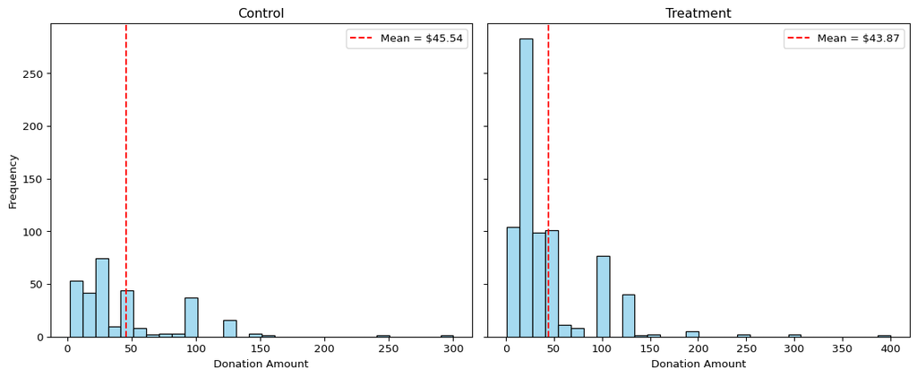

Distribution of Donation Amounts Among Donors

```
T-test (unconditional): t = 1.8605, p = 0.0628

Linear regression (unconditional):
                             OLS Regression Results
==============================================================================
Dep. Variable:                 amount   R-squared:                       0.000
Model:                            OLS   Adj. R-squared:                  0.000
Method:                 Least Squares   F-statistic:                     3.461
Date:                Wed, 23 Apr 2025   Prob (F-statistic):             0.0628
Time:                        08:17:42   Log-Likelihood:            -1.7946e+05
No. Observations:               50083   AIC:                         3.589e+05
Df Residuals:                   50081   BIC:                         3.589e+05
Df Model:                           1
Covariance Type:            nonrobust
==============================================================================
                 coef    std err          t      P>|t|      [0.025      0.975]
------------------------------------------------------------------------------
Intercept      0.8133      0.067     12.063      0.000       0.681       0.945
treatment      0.1536      0.083      1.861      0.063      -0.008       0.315
==============================================================================
Omnibus:                    96861.113   Durbin-Watson:                   2.008
Prob(Omnibus):                  0.000   Jarque-Bera (JB):        240735713.635
Skew:                          15.297   Prob(JB):                         0.00
Kurtosis:                     341.269   Cond. No.                         3.23
==============================================================================

Notes:
[1] Standard Errors assume that the covariance matrix of the errors is correctly specified.

Linear regression (conditional on giving):
                             OLS Regression Results
==============================================================================
Dep. Variable:                 amount   R-squared:                       0.000
Model:                            OLS   Adj. R-squared:                 -0.001
Method:                 Least Squares   F-statistic:                    0.3374
Date:                Wed, 23 Apr 2025   Prob (F-statistic):              0.561
Time:                        08:17:42   Log-Likelihood:                -5326.8
No. Observations:                1034   AIC:                         1.066e+04
Df Residuals:                    1032   BIC:                         1.067e+04
Df Model:                           1
Covariance Type:            nonrobust
==============================================================================
                 coef    std err          t      P>|t|      [0.025      0.975]
------------------------------------------------------------------------------
Intercept     45.5403      2.423     18.792      0.000      40.785      50.296
treatment     -1.6684      2.872     -0.581      0.561      -7.305       3.968
==============================================================================
Omnibus:                      587.258   Durbin-Watson:                   2.031
Prob(Omnibus):                  0.000   Jarque-Bera (JB):             5623.279
Skew:                           2.464   Prob(JB):                         0.00
Kurtosis:                      13.307   Cond. No.                         3.49
==============================================================================

Notes:
[1] Standard Errors assume that the covariance matrix of the errors is correctly specified.
```

```python
import pandas as pd
import matplotlib.pyplot as plt
import seaborn as sns
from scipy.stats import ttest_ind
import statsmodels.formula.api as smf

# Filter to needed columns
df_amt = df[['treatment', 'gave', 'amount']].dropna()

# --- Unconditional analysis (all participants) ---
treat_amt = df_amt[df_amt['treatment'] == 1]['amount']
control_amt = df_amt[df_amt['treatment'] == 0]['amount']

# T-test
t_stat, p_val = ttest_ind(treat_amt, control_amt)

# Regression
model_all = smf.ols('amount ~ treatment', data=df_amt).fit()

# --- Conditional analysis (only among donors) ---
df_donors = df_amt[df_amt['gave'] == 1]
model_donors = smf.ols('amount ~ treatment', data=df_donors).fit()

# --- Histograms ---
fig, axes = plt.subplots(1, 2, figsize=(12, 5), sharey=True)

for ax, group in zip(axes, [0, 1]):
    subset = df_donors[df_donors['treatment'] == group]['amount']
    mean_val = subset.mean()
    sns.histplot(subset, bins=30, ax=ax, color='skyblue', edgecolor='black')
    ax.axvline(mean_val, color='red', linestyle='--', label=f'Mean = ${mean_val:.2f}')
    ax.set_title("Control" if group == 0 else "Treatment")
    ax.set_xlabel("Donation Amount")
    ax.set_ylabel("Frequency")
    ax.legend()

plt.tight_layout()
plt.show()

# Print summary stats
print(f"T-test (unconditional): t = {t_stat:.4f}, p = {p_val:.4f}")
print("\nLinear regression (unconditional):\n", model_all.summary())
print("\nLinear regression (conditional on giving):\n", model_donors.summary())
```

## 4 Simulation Experiment

As a reminder of how the t-statistic “works,” in this section I use simulation to demonstrate the Law of Large Numbers and the Central Limit Theorem.

Suppose the true distribution of respondents who do not get a charitable donation match is Bernoulli with probability p=0.018 that a donation is made.

Further suppose that the true distribution of respondents who do get a charitable donation match of any size is Bernoulli with probability p=0.022 that a donation is made.

### 4.1 Law of Large Numbers

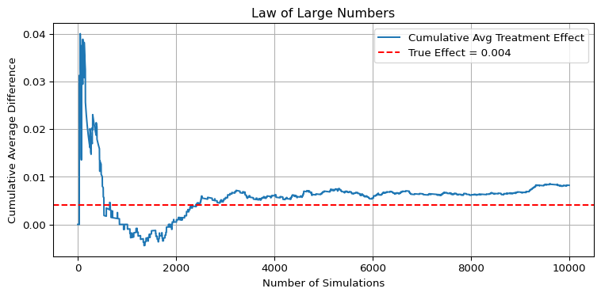

Cumulative Average Treatment Effect (Law of Large Numbers)

```python
import numpy as np
import matplotlib.pyplot as plt

# Set seed for reproducibility
np.random.seed(42)

# Simulate 10,000 draws from control and treatment Bernoulli distributions
n = 10_000
control = np.random.binomial(1, 0.018, n)
treatment = np.random.binomial(1, 0.022, n)

# Compute differences and cumulative average
diffs = treatment - control
cumulative_avg = np.cumsum(diffs) / np.arange(1, n+1)

# Plot
plt.figure(figsize=(8, 4))
plt.plot(cumulative_avg, label='Cumulative Avg Treatment Effect')
plt.axhline(y=0.004, color='red', linestyle='--', label='True Effect = 0.004')
plt.xlabel('Number of Simulations')
plt.ylabel('Cumulative Average Difference')
plt.title('Law of Large Numbers')
plt.legend()
plt.grid(True)
plt.tight_layout()
plt.show()
```

[output not shown]

### 4.2 Central Limit Theorem

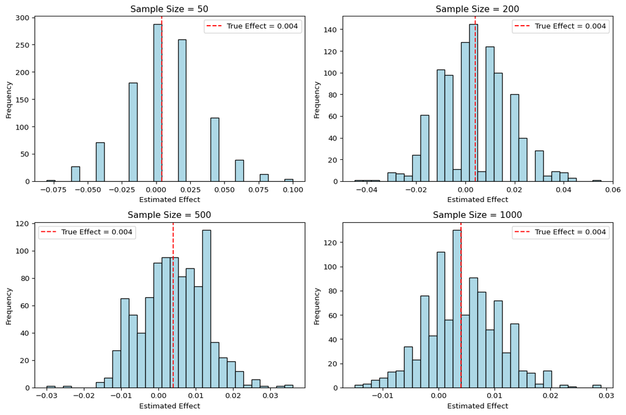

Sampling Distributions at Varying Sample Sizes (CLT)

```python
import matplotlib.pyplot as plt

sample_sizes = [50, 200, 500, 1000]
true_effect = 0.004
fig, axes = plt.subplots(2, 2, figsize=(12, 8))

for i, n in enumerate(sample_sizes):
    means = []
    for _ in range(1000):
        control_sample = np.random.binomial(1, 0.018, n)
        treatment_sample = np.random.binomial(1, 0.022, n)
        diff = treatment_sample.mean() - control_sample.mean()
        means.append(diff)

    ax = axes[i//2, i%2]
    ax.hist(means, bins=30, color='lightblue', edgecolor='black')
    ax.axvline(true_effect, color='red', linestyle='--', label='True Effect = 0.004')
    ax.set_title(f"Sample Size = {n}")
    ax.set_xlabel("Estimated Effect")
    ax.set_ylabel("Frequency")
    ax.legend()

plt.tight_layout()
plt.show()
```

```
> Each histogram shows the distribution of **1,000 average treatment effects** computed from repeated samples of size 50, 200, 500, and 1000. As the sample size increases:
>
> - The center of the distribution remains near **0.004**, the true effect
> - The **spread (standard deviation)** of the estimates shrinks
> - The shape becomes increasingly **bell-shaped and normal**
>
> This is the **Central Limit Theorem** in action: the sampling distribution of the mean approaches a normal distribution, even though the underlying data (Bernoulli draws) are not normally distributed.
```